# Untitled

# tidymodel tutorial

tidymodel 설명

```r
data(ames)
```

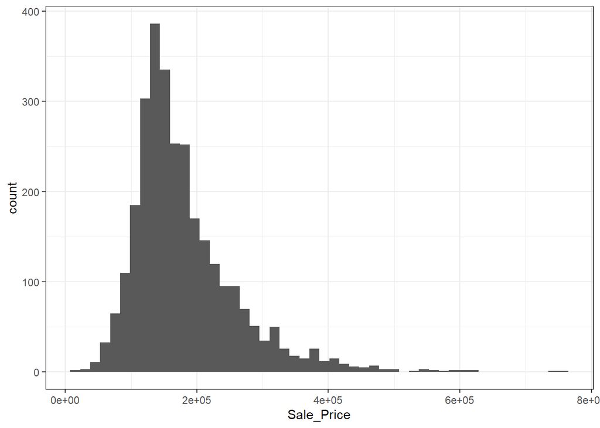

```r
theme_set(theme_bw())
ggplot(ames, aes(x = Sale_Price)) +
  geom_histogram(bins = 50)
```

```r
ames <- ames %>% mutate(Sale_Price = log10(Sale_Price))
ames %>% head()
```

```
## # A tibble: 6 x 74
##   MS_SubClass MS_Zoning Lot_Frontage Lot_Area Street Alley Lot_Shape
##   <fct>       <fct>            <dbl>    <int> <fct>  <fct> <fct>
## 1 One_Story_~ Resident~          141    31770 Pave   No_A~ Slightly~
## 2 One_Story_~ Resident~           80    11622 Pave   No_A~ Regular
## 3 One_Story_~ Resident~           81    14267 Pave   No_A~ Slightly~
## 4 One_Story_~ Resident~           93    11160 Pave   No_A~ Regular
## 5 Two_Story_~ Resident~           74    13830 Pave   No_A~ Slightly~
## 6 Two_Story_~ Resident~           78     9978 Pave   No_A~ Slightly~
## # ... with 67 more variables: Land_Contour <fct>, Utilities <fct>,
## #   Lot_Config <fct>, Land_Slope <fct>, Neighborhood <fct>, Condition_1 <fct>,
## #   Condition_2 <fct>, Bldg_Type <fct>, House_Style <fct>, Overall_Cond <fct>,
## #   Year_Built <int>, Year_Remod_Add <int>, Roof_Style <fct>, Roof_Matl <fct>,
## #   Exterior_1st <fct>, Exterior_2nd <fct>, Mas_Vnr_Type <fct>,
## #   Mas_Vnr_Area <dbl>, Exter_Cond <fct>, Foundation <fct>, Bsmt_Cond <fct>,
## #   Bsmt_Exposure <fct>, BsmtFin_Type_1 <fct>, BsmtFin_SF_1 <dbl>,
## #   BsmtFin_Type_2 <fct>, BsmtFin_SF_2 <dbl>, Bsmt_Unf_SF <dbl>,
## #   Total_Bsmt_SF <dbl>, Heating <fct>, Heating_QC <fct>, Central_Air <fct>,
## #   Electrical <fct>, First_Flr_SF <int>, Second_Flr_SF <int>,
## #   Gr_Liv_Area <int>, Bsmt_Full_Bath <dbl>, Bsmt_Half_Bath <dbl>,
## #   Full_Bath <int>, Half_Bath <int>, Bedroom_AbvGr <int>, Kitchen_AbvGr <int>,
## #   TotRms_AbvGrd <int>, Functional <fct>, Fireplaces <int>, Garage_Type <fct>,
## #   Garage_Finish <fct>, Garage_Cars <dbl>, Garage_Area <dbl>,
## #   Garage_Cond <fct>, Paved_Drive <fct>, Wood_Deck_SF <int>,
## #   Open_Porch_SF <int>, Enclosed_Porch <int>, Three_season_porch <int>,
## #   Screen_Porch <int>, Pool_Area <int>, Pool_QC <fct>, Fence <fct>,
## #   Misc_Feature <fct>, Misc_Val <int>, Mo_Sold <int>, Year_Sold <int>,
## #   Sale_Type <fct>, Sale_Condition <fct>, Sale_Price <dbl>, Longitude <dbl>,
## #   Latitude <dbl>
```

## Data split

- prop : training data 비율
- strata : classification 문제에서 범주 간 불균형 문제를 해결하기 위해 층을 나누고 샘플링 진행. regression 문제에서는 사분위수를 기준으로 나누고 샘플링 진행

```r
set.seed(123)
ames_split <- initial_split(ames, prop = 0.8, strata = Sale_Price)
ames_train <- training(ames_split)
ames_test <- testing(ames_split)
```

## Feature engineering

tidymodel 패키지는 복잡한 데이터 전처리 과정을 간소화시키기 위해서 총 3단계의 데이터 전처리 프로세스를 도입했다. 각 단계는 recipe(요리 방식을 정의하는 단계), prep(요리 재료를 준비하는 단계), bake(요리를 하는 단계)로 구성된다.

각 단계별로 살펴보면 첫 번째로, recipe는 사전에 처리할 함수를 정의하는 단계이다. recipe와 연동되는 데이터 전처리에 필요한 함수가 사전 정의되어 있으며, 이를 이용해서 데이터 전처리 과정을 정의한다. 두 번째로, prep은 training set으로 부터 recipe에서 정의한 데이터 전처리 과정을 계산하는 단계이다. 계산 결과를 바로 output으로 출력할 수 없고 bake 함수를 이용해야만 output이 출력된다. bake는 data set에 적용한 prep을 적용해서 output으로 도출하는 단계이다.

사실 사용하면서 데이터 전처리 과정을 사전 정의한다는 개념이 익숙하지 않았는데 각 단계별 세부 내용을 기술하면서 나름의 이유를 설명해보도록 하겠다.

### Recipe

데이터 전처리를 위한 단계를 정의하는 object이다. 특이한 점은 즉시 실행되지 않고 단계를 **정의**만한다는 것이다. 왜 번거롭게 recipe를 사용해야 하는지 의문이 생길 수 있다.

Recipe의 장점은 다음과 같다.

- recipe object를 여러가지 모델에 재사용 가능
- recipe 내에 사전 정의된 함수를 이용하면 코드의 간결성 확보 가능

즉, recipe를 이용해서 사전 정의된 object는 linear regression, random forest, xgboost 등등 tidymodel과 연동된 여러가지 모델에 대해 동일하게 적용할 수 있다. 또 recipe에는 생각보다 다양한 데이터 전처리 관련 함수가 있는데 이를 이용하면 기존에 각 변수별로 정의를 해주어야했던 데이터 전처리 과정을 간결하고 가독성 있는 코드로 구현이 가능하다.

세부적인 recipe 내에 step_fun은 다음과 같다.

- Normalization
  - step_center(var) - 평균을 빼서 중심 이동
  - step_normalize(var) - 평균 빼고, 분산으로 나눠서 표준화
- Filters
  - step_corr(threshold = 0.9) - 상관계수의 절대값이 큰 변수 제거
  - step_rm(var) - 지정된 변수 제거
  - step_zv() - 분산이 0인 변수 제거
  - step_nzv() - 값이 거의 0인 변수 제거
- Transformations
  - step_log(var, base = exp(1) ) - 변수 로그 변환
  - step_logit(var) - 변수 로짓 변환
  - step_poly(var, degree = 2) - 변수에 polynomial term 추가(I()가 아닌 poly()와 동일, 즉 orthogonal polynomial 이용)
  - step_BoxCox() - 변수 Boxcox 변환

  ```r
  examples <- data.frame(matrix(runif(40), ncol = 2))
  rec <- recipe(~ X1 + X2, data = examples)
  rec %>%
      step_logit(all_predictors()) %>%
      prep() %>%
      bake(examples)
  ```

  ```
  ## # A tibble: 20 x 2
  ##         X1      X2
  ##      <dbl>   <dbl>
  ##  1  0.337   1.79
  ##  2  0.701   0.838
  ##  3  0.0453  0.774
  ##  4  1.17   -0.628
  ##  5  2.24    0.220
  ##  6  1.52   -1.84
  ##  7 -2.56    1.29
  ##  8 -5.54    2.06
  ##  9 -2.90   -1.36
  ## 10  1.87    1.21
  ## 11  0.307   0.390
  ## 12 -0.782   3.12
  ## 13  3.16   -1.67
  ## 14  0.369   0.104
  ## 15  0.126   1.93
  ## 16 -0.473   1.90
  ## 17 -0.756  -3.72
  ## 18  1.44    3.70
  ## 19 -3.13   -0.0391
  ## 20 -0.559  -0.451
  ```

- Discretization
  - step_discretize(var, num_breaks = 4) - 연속형 변수 이산형으로 변환
  - step_cut() - 연속형 변수를 지정한 값을 기준으로 이산형으로 변환
    - include_outside_range - 지정한 범위를 넘어선 값을 양끝 break에 포함시킬지 여부. default = FALSE이며 결측치 처리됨
    - breaks - 절단 기준이 되는 값

  ```r
  df <- data.frame(x = 1:10, y = 5:14)
  rec <- recipe(df)
  rec %>%
      step_cut(x, y, breaks = c(6, 9), include_outside_range = TRUE) %>%
      prep() %>%
      bake(df)
  ```

  ```
  ## # A tibble: 10 x 2
  ##    x       y
  ##    <fct>   <fct>
  ##  1 [min,6] [min,6]
  ##  2 [min,6] [min,6]
  ##  3 [min,6] (6,9]
  ##  4 [min,6] (6,9]
  ##  5 [min,6] (6,9]
  ##  6 [min,6] (9,max]
  ##  7 (6,9]   (9,max]
  ##  8 (6,9]   (9,max]
  ##  9 (6,9]   (9,max]
  ## 10 (9,max] (9,max]
  ```

- Dummy variables and encodings
  - step_date() - date 변수에서 year, month, day of week 변수를 새롭게 생성
    - feature = c(‘dow’, ‘month’, ‘year’) - 요일, 달, 연도 변수 추가
    - abbr = T - Sunday or Sun
    - label = Sunday or number
  - step_holiday() - date 변수에서 공휴일에 관한 이진변수 새롭게 생성
    - holidays = c(‘LaborDay’, ‘NewYearDay’, ‘ChristmasDay’)
    - holidays = timeDate::listHolidays(‘US’)

  ```r
  examples <- data.frame(someday = ymd("2000-12-20") + days(0:40))
  holiday_rec <- recipe(~ someday, examples) %>%
      step_holiday(all_predictors())

  holiday_rec <- prep(holiday_rec, training = examples)
  holiday_values <- bake(holiday_rec, new_data = examples)
  holiday_values
  ```

  ```
  ## # A tibble: 41 x 4
  ##    someday    someday_LaborDay someday_NewYearsDay someday_ChristmasDay
  ##    <date>                <dbl>               <dbl>                <dbl>
  ##  1 2000-12-20                0                   0                    0
  ##  2 2000-12-21                0                   0                    0
  ##  3 2000-12-22                0                   0                    0
  ##  4 2000-12-23                0                   0                    0
  ##  5 2000-12-24                0                   0                    0
  ##  6 2000-12-25                0                   0                    1
  ##  7 2000-12-26                0                   0                    0
  ##  8 2000-12-27                0                   0                    0
  ##  9 2000-12-28                0                   0                    0
  ## 10 2000-12-29                0                   0                    0
  ## # ... with 31 more rows
  ```

  - step_dummy() - character or factor 변수를 더미변수로 변환
    - one_hot = TRUE - C +1개의 더미변수 생성(one_hot = F: C-1개 더미변수 생성

  ```r
  iris <- iris %>% mutate(original = Species)
  iris_rec <- recipe( ~ ., data = iris)
  ref_cell <-
    iris_rec %>%
    step_dummy(Species) %>%
    prep(training = iris)

  juice(ref_cell, original, starts_with("Species")) %>%
      distinct()
  ```

  ```
  ## # A tibble: 3 x 3
  ##   original   Species_versicolor Species_virginica
  ##   <fct>                   <dbl>             <dbl>
  ## 1 setosa                      0                 0
  ## 2 versicolor                  1                 0
  ## 3 virginica                   0                 1
  ```

  - step_other() - 범주형 변수의 level이 여러개일 때, 하위 범주를 기타로 묶음
    - threshold = 0.05 - 하위 5% 범주는 기타로 묶임
    - other : 기타로 지정할 level 이름 지정
  - step_interact() - 상호작용 항 추가

  ```r
  iris_int <-
    iris_rec %>%
    step_interact( ~ Sepal.Width:Sepal.Length) %>%
    prep(training = iris)
  summary(iris_int)
  ```

  ```
  ## # A tibble: 7 x 4
  ##   variable                   type    role      source
  ##   <chr>                      <chr>   <chr>     <chr>
  ## 1 Sepal.Length               numeric predictor original
  ## 2 Sepal.Width                numeric predictor original
  ## 3 Petal.Length               numeric predictor original
  ## 4 Petal.Width                numeric predictor original
  ## 5 Species                    nominal predictor original
  ## 6 original                   nominal predictor original
  ## 7 Sepal.Width_x_Sepal.Length numeric predictor derived
  ```

```r
table(ames_train$Bldg_Type)
```

```
##
##   OneFam TwoFmCon   Duplex    Twnhs   TwnhsE
##     1945       51       83       79      188
```

```r
simple_ames <-
  recipe(Sale_Price ~ Neighborhood + Gr_Liv_Area + Year_Built + Bldg_Type,
         data = ames_train) %>%
  step_log(Gr_Liv_Area, base = 10) %>%
  step_dummy(all_nominal())
simple_ames
```

```
## Data Recipe
##
## Inputs:
##
##       role #variables
##    outcome          1
##  predictor          4
##
## Operations:
##
## Log transformation on Gr_Liv_Area
## Dummy variables from all_nominal()
```

### Prep

recipe object를 설정한 후에 prep을 이용해서 계산을 한다.

```r
simple_ames <- prep(simple_ames, training = ames_train)
simple_ames
```

```
## Data Recipe
##
## Inputs:
##
##       role #variables
##    outcome          1
##  predictor          4
##
## Training data contained 2346 data points and no missing data.
##
## Operations:
##
## Log transformation on Gr_Liv_Area [trained]
## Dummy variables from Neighborhood, Bldg_Type [trained]
```

### Bake

recipe, prep을 거쳐서 전처리된 데이터를 이용해서 적용을 해보는 단계이다.

데이터 전처리를 완료한 결과를 보고 싶으면 bake 함수를 이용하면 되는데 training data를 기준으로 이전에 데이터 전처리를 했기 때문에 **new_data = training set을** 넣고 중복 계산할 필요가 없다.

```r
bake(simple_ames, new_data = NULL)
```

```
## # A tibble: 2,346 x 35
##    Gr_Liv_Area Year_Built Sale_Price Neighborhood_Co~ Neighborhood_Ol~
##          <dbl>      <int>      <dbl>            <dbl>            <dbl>
##  1        3.22       1960       5.33                0                0
##  2        2.95       1961       5.02                0                0
##  3        3.12       1958       5.24                0                0
##  4        3.21       1997       5.28                0                0
##  5        3.21       1998       5.29                0                0
##  6        3.13       2001       5.33                0                0
##  7        3.11       1992       5.28                0                0
##  8        3.21       1995       5.37                0                0
##  9        3.22       1993       5.25                0                0
## 10        3.17       1998       5.26                0                0
## # ... with 2,336 more rows, and 30 more variables: Neighborhood_Edwards <dbl>,
## #   Neighborhood_Somerset <dbl>, Neighborhood_Northridge_Heights <dbl>,
## #   Neighborhood_Gilbert <dbl>, Neighborhood_Sawyer <dbl>,
## #   Neighborhood_Northwest_Ames <dbl>, Neighborhood_Sawyer_West <dbl>,
## #   Neighborhood_Mitchell <dbl>, Neighborhood_Brookside <dbl>,
## #   Neighborhood_Crawford <dbl>, Neighborhood_Iowa_DOT_and_Rail_Road <dbl>,
## #   Neighborhood_Timberland <dbl>, Neighborhood_Northridge <dbl>,
## #   Neighborhood_Stone_Brook <dbl>,
## #   Neighborhood_South_and_West_of_Iowa_State_University <dbl>,
## #   Neighborhood_Clear_Creek <dbl>, Neighborhood_Meadow_Village <dbl>,
## #   Neighborhood_Briardale <dbl>, Neighborhood_Bloomington_Heights <dbl>,
## #   Neighborhood_Veenker <dbl>, Neighborhood_Northpark_Villa <dbl>,
## #   Neighborhood_Blueste <dbl>, Neighborhood_Greens <dbl>,
## #   Neighborhood_Green_Hills <dbl>, Neighborhood_Landmark <dbl>,
## #   Neighborhood_Hayden_Lake <dbl>, Bldg_Type_TwoFmCon <dbl>,
## #   Bldg_Type_Duplex <dbl>, Bldg_Type_Twnhs <dbl>, Bldg_Type_TwnhsE <dbl>
```

test 데이터를 기준으로 전처리를 진행할 때 **new_data = test set**을 넣어주기만 하면 recipe, prep을 재지정해줄 필요 없이 곧바로 데이터 전처리가 가능하다.

```r
test_ex <- bake(simple_ames, new_data = ames_test)
names(test_ex) %>% head()
```

```
## [1] "Gr_Liv_Area"                "Year_Built"
## [3] "Sale_Price"                 "Neighborhood_College_Creek"
## [5] "Neighborhood_Old_Town"      "Neighborhood_Edwards"
```

```r
test_ex
```

```
## # A tibble: 584 x 35
##    Gr_Liv_Area Year_Built Sale_Price Neighborhood_Co~ Neighborhood_Ol~
##          <dbl>      <int>      <dbl>            <dbl>            <dbl>
##  1        3.32       1968       5.39                0                0
##  2        3.26       1999       5.28                0                0
##  3        3.07       1992       5.27                0                0
##  4        3.13       1990       5.23                0                0
##  5        3.13       1999       5.26                0                0
##  6        3.04       1971       5.02                0                0
##  7        3.23       2007       5.49                0                0
##  8        3.12       2005       5.30                0                0
##  9        3.29       2002       5.34                0                0
## 10        3.39       1998       5.55                0                0
## # ... with 574 more rows, and 30 more variables: Neighborhood_Edwards <dbl>,
## #   Neighborhood_Somerset <dbl>, Neighborhood_Northridge_Heights <dbl>,
## #   Neighborhood_Gilbert <dbl>, Neighborhood_Sawyer <dbl>,
## #   Neighborhood_Northwest_Ames <dbl>, Neighborhood_Sawyer_West <dbl>,
## #   Neighborhood_Mitchell <dbl>, Neighborhood_Brookside <dbl>,
## #   Neighborhood_Crawford <dbl>, Neighborhood_Iowa_DOT_and_Rail_Road <dbl>,
## #   Neighborhood_Timberland <dbl>, Neighborhood_Northridge <dbl>,
## #   Neighborhood_Stone_Brook <dbl>,
## #   Neighborhood_South_and_West_of_Iowa_State_University <dbl>,
## #   Neighborhood_Clear_Creek <dbl>, Neighborhood_Meadow_Village <dbl>,
## #   Neighborhood_Briardale <dbl>, Neighborhood_Bloomington_Heights <dbl>,
## #   Neighborhood_Veenker <dbl>, Neighborhood_Northpark_Villa <dbl>,
## #   Neighborhood_Blueste <dbl>, Neighborhood_Greens <dbl>,
## #   Neighborhood_Green_Hills <dbl>, Neighborhood_Landmark <dbl>,
## #   Neighborhood_Hayden_Lake <dbl>, Bldg_Type_TwoFmCon <dbl>,
## #   Bldg_Type_Duplex <dbl>, Bldg_Type_Twnhs <dbl>, Bldg_Type_TwnhsE <dbl>
```

## 참고 문헌

[tidymodel with R bookdown](https://www.tmwr.org/ames.html)

[tidymodel recipe object](https://recipes.tidymodels.org/reference/index.html)